# Building a mesh in INLA

Guillaume Blanchet & Steve Vissault

November 21th, 2019

# Introduction

This particular vignette was written to get users started on how to build a Delaunay triangulation (or a mesh) that will serve as a basis to construct the spatial component of the models through an SPDE approach.

Properly choosing the structure of the mesh is essential for the model estimation to be carried out properly. Detailed explanation on the dos and don’ts of constructing a mesh are presented in section 1.3 of the [R-INLA tutorial on SPDE models](http://inla.r-inla-download.org/r-inla.org/tutorials/spde/html/).

Without repeating all the details presented in the above mentioned tutorial, this vignette is designed to get users started. What is important to consider when constructing the mesh is that the triangles in the mesh be roughly of the same size. In addition, it is a good idea to include a buffer zone around the sampling area to prevent problems related to edge effect that may arise. This may be done explicitly or implicitly depending on the way the mesh is contructed.

```r
library(INLA)
library(raster)
```

# Data

## Species data

```r
# Load species data
load("assets/data/mite.spdf.rda")
```

## Environmental data

```r
# Environmental data
load("assets/data/mite.envRaster.rda")
```

## Building the mesh

For our illustration, let’s first build a `SpatialPolygons` outlining the sampling area. Note that this step is not necessary to construct the mesh but it often the case that a `SpatialPolygons` object is available to delineate the study area.

```r
poly <- Polygon(matrix(c(0,0,2.6,2.6,0,0,10,10,0,0),
                       nrow = 5, ncol = 2))
spacePoly <- SpatialPolygons(list(Polygons(list(poly), ID = 1)),
                             proj4string = crs(mite.envRaster))
```

Using `spacePoly`, let’s construct the mesh. Usually, constructing the mesh requires a few trials to get exactly what is needed for the species understudy. So, do not despair!

The function used to construct the mesh comes directly from `INLA`. If you dig deep into `INLA`, you will find that there existe a few functions to construct meshes. Here we will used `inla.mesh.2d`. At this point it becomes important to read the help file of `inla.mesh.2d` to fully understand the meaning of each argument that can be tweaked to construct the mesh you want to have.

Here are a few notes on some of the arguments of `inla.mesh.2d` that are worth knowing:

`max.edge` : It is a length given in the same units as the coordinates of the studied system.

`cutoff` : It is a length given in the same units as the coordinates of the studied system.

Here are a few example of mesh that can be drawn for our study site.

### Using a `SpatialPolygons` as boundaries

Using only `max.edge` and `offset` to define the mesh, it is possible to obtain a reasonably good mesh.

```r
meshPoly1 <- inla.mesh.2d(boundary = spacePoly, max.edge = 2,
                          offset = c(2,2), cutoff = 0.5,
                          crs = crs(mite.envRaster))
meshPoly2 <- inla.mesh.2d(boundary = spacePoly, max.edge = 2,
                          offset = c(1,1), cutoff = 0.5,
                          crs = crs(mite.envRaster))
meshPoly3 <- inla.mesh.2d(boundary = spacePoly, max.edge = 0.5,
                          offset = c(2,2), cutoff = 0.5,
                          crs = crs(mite.envRaster))
meshPoly4 <- inla.mesh.2d(boundary = spacePoly, max.edge = 0.5,
                          offset = c(1,1), cutoff = 0.5,
                          crs = crs(mite.envRaster))
```

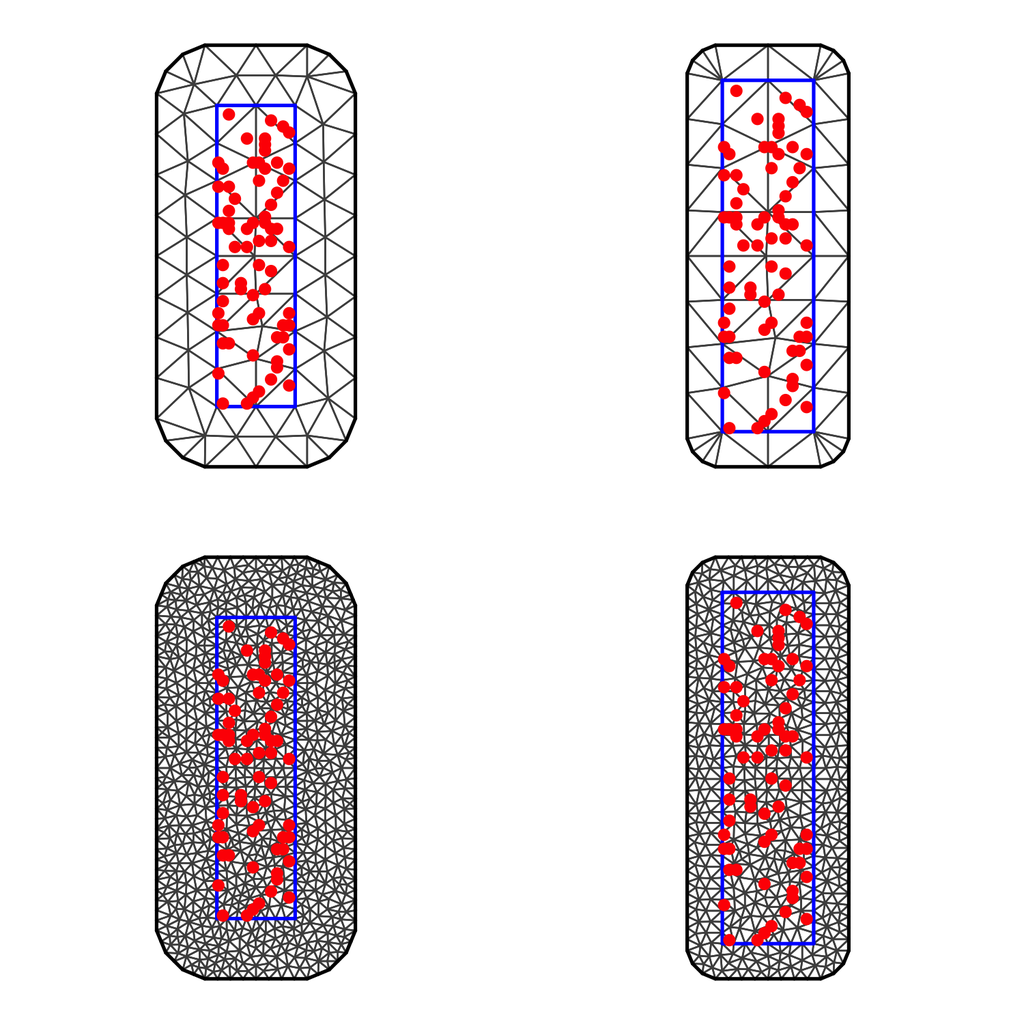

```r
par(mfrow = c(2,2), mar = c(1,1,1,1))

plot(meshPoly1, main = "", asp = 1)
points(coordinates(mite.spdf), pch = 19, col = "red")

plot(meshPoly2, main = "", asp = 1)
points(coordinates(mite.spdf), pch = 19, col = "red")

plot(meshPoly3, main = "", asp = 1)
points(coordinates(mite.spdf), pch = 19, col = "red")

plot(meshPoly4, main = "", asp = 1)
points(coordinates(mite.spdf), pch = 19, col = "red")
```

If computational time is an issue, it is useful to compare the number of edges in the mesh. The larger the number of edges the longer it will take for model estimation. This can be checked with the following code.

```r
meshPoly1$n
```

```
## [1] 82
```

```r
meshPoly2$n
```

```
## [1] 58
```

```r
meshPoly3$n
```

```
## [1] 921
```

```r
meshPoly4$n
```

```
## [1] 590
```

Note that `meshPoly4` is probably a good candidate at this point because it is a fine enough mesh to efficiently capture the spatial variation in the data. In addition, it has a reasonable number of edges, although if it turned out to be too long to run the analysis using such a mesh, it might be worth it to increase the `max.edge` values and thus reduced the number of edges in the analysis.

### Using the sampled locations as a basis

This can be done using the argument `loc`

```r
meshLoc1 <- inla.mesh.2d(loc = mite.spdf, max.edge = 2,
                         offset = c(1,1), cutoff = 0.5,
                         crs = crs(mite.envRaster))
meshLoc2 <- inla.mesh.2d(loc = mite.spdf, max.edge = 0.5,
                         offset = c(1,1), cutoff = 0.5,
                         crs = crs(mite.envRaster))
```

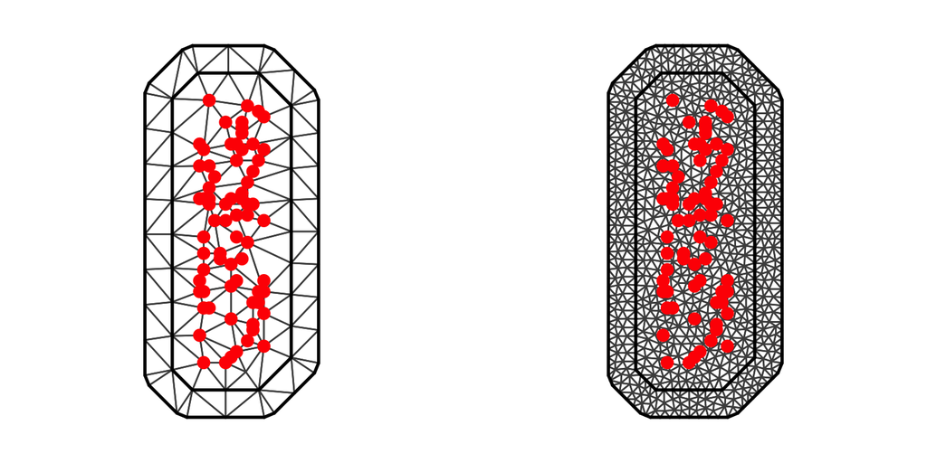

```r
par(mfrow = c(1,2), mar = c(1,1,1,1))

plot(meshLoc1, main = "", asp = 1)
points(coordinates(mite.spdf), pch = 19, col = "red")

plot(meshLoc2, main = "", asp = 1)
points(coordinates(mite.spdf), pch = 19, col = "red")
```

```r
# Number of edges in the mesh
meshLoc1$n
```

```
## [1] 98
```

```r
meshLoc2$n
```

```
## [1] 890
```

or the argument `loc.domain`

```r
meshDom1 <- inla.mesh.2d(loc.domain = mite.spdf, max.edge = 2,
                         offset = c(1,1), cutoff = 0.5,
                         crs = crs(mite.envRaster))
meshDom2 <- inla.mesh.2d(loc.domain = mite.spdf, max.edge = 0.6,
                         offset = c(1,1), cutoff = 0.5,
                         crs = crs(mite.envRaster))
meshDom3 <- inla.mesh.2d(loc.domain = mite.spdf, max.edge = 0.5,
                         offset = c(0.5,0.5), cutoff = 0.5,
                         crs = crs(mite.envRaster))
```

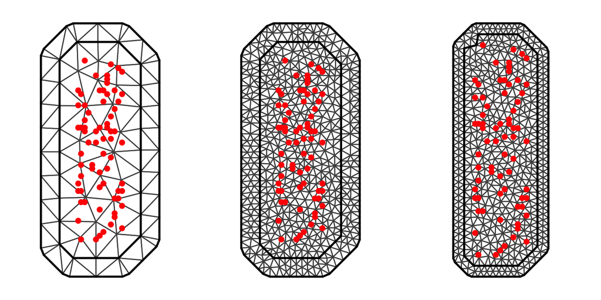

```r
par(mfrow = c(1,3), mar = c(1,1,1,1))

plot(meshDom1, main = "", asp = 1)
points(coordinates(mite.spdf), pch = 19, col = "red")

plot(meshDom2, main = "", asp = 1)
points(coordinates(mite.spdf), pch = 19, col = "red")

plot(meshDom3, main = "", asp = 1)
points(coordinates(mite.spdf), pch = 19, col = "red")
```

```r
# Number of edges in the mesh
meshDom1$n
```

```
## [1] 77
```

```r
meshDom2$n
```

```
## [1] 608
```

```r
meshDom3$n
```

```
## [1] 596
```